# Reproducible_Research_Proj_2: Harmful Events

Adam Warlock

May 17, 2016

## Synopsis

### Assignment

The basic goal of this assignment is to explore the NOAA Storm Database and answer some basic questions about severe weather events. You must use the database to answer the questions below and show the code for your entire analysis. Your analysis can consist of tables, figures, or other summaries. You may use any R package you want to support your analysis.

### Questions

Your data analysis must address the following questions:

1. Across the United States, which types of events (as indicated in the EVTYPE variable) are most harmful with respect to population health?
2. Across the United States, which types of events have the greatest economic consequences?

### Plan

1. Load data into R
2. Find column names and identifiy all EVTYPE.
3. From names, find out what column that will be used.

### Data Processing

```r
#This assumes that the Storm data has already been downloaded and extracted
#Set working directory
setwd("C:/Users/Herbert/Desktop/R Programing/4_Reproducible Research/Course_Project_2")
storm <- read.csv("repdata_data_StormData.csv")
names(storm)
```

```
##  [1] "STATE__"    "BGN_DATE"   "BGN_TIME"   "TIME_ZONE"  "COUNTY"
##  [6] "COUNTYNAME" "STATE"      "EVTYPE"     "BGN_RANGE"  "BGN_AZI"
## [11] "BGN_LOCATI" "END_DATE"   "END_TIME"   "COUNTY_END" "COUNTYENDN"
## [16] "END_RANGE"  "END_AZI"    "END_LOCATI" "LENGTH"     "WIDTH"
## [21] "F"          "MAG"        "FATALITIES" "INJURIES"   "PROPDMG"
## [26] "PROPDMGEXP" "CROPDMG"    "CROPDMGEXP" "WFO"        "STATEOFFIC"
## [31] "ZONENAMES"  "LATITUDE"   "LONGITUDE"  "LATITUDE_E" "LONGITUDE_"
## [36] "REMARKS"    "REFNUM"
```

From the names, appears we only need the following coloumns to complete this exercise  
*STATE*  
*EVTYPE*  
*FATALITIES*  
*INJURIES*  
*PROPDMG*  
*CROPDMG*

```r
stormN <- storm[,c("STATE", "EVTYPE", "FATALITIES", "INJURIES","PROPDMG", "CROPDMG")]
head(stormN)
```

```
##   STATE  EVTYPE FATALITIES INJURIES PROPDMG CROPDMG
## 1    AL TORNADO          0       15    25.0       0
## 2    AL TORNADO          0        0     2.5       0
## 3    AL TORNADO          0        2    25.0       0
## 4    AL TORNADO          0        2     2.5       0
## 5    AL TORNADO          0        2     2.5       0
## 6    AL TORNADO          0        6     2.5       0
```

```r
#Because all the columns are factors, we need to convert FATALITIES-CROPDMG to numeric
stormN[,3:6] <- sapply(stormN[,3:6], as.numeric)
```

### Most Harmful

```r
library(ggplot2)
Most_Harmful <- aggregate(FATALITIES~EVTYPE, stormN, sum, na.rm = TRUE)
#Ordering the list will help make it a little easier when graphing
Most_Harmful <-Most_Harmful[order(Most_Harmful$FATALITIES, decreasing = TRUE),]
#Then we need to locate which is most harful related to population health
ID_Most_Harm <- which.max(Most_Harmful[,2])
Most_Harmful[ID_Most_Harm,]
```

```
##      EVTYPE FATALITIES
## 834 TORNADO       5633
```

```r
top5 <- head(Most_Harmful,5)
top5
```

```
##             EVTYPE FATALITIES
## 834        TORNADO       5633
## 130 EXCESSIVE HEAT       1903
## 153    FLASH FLOOD        978
## 275           HEAT        937
## 464      LIGHTNING        816
```

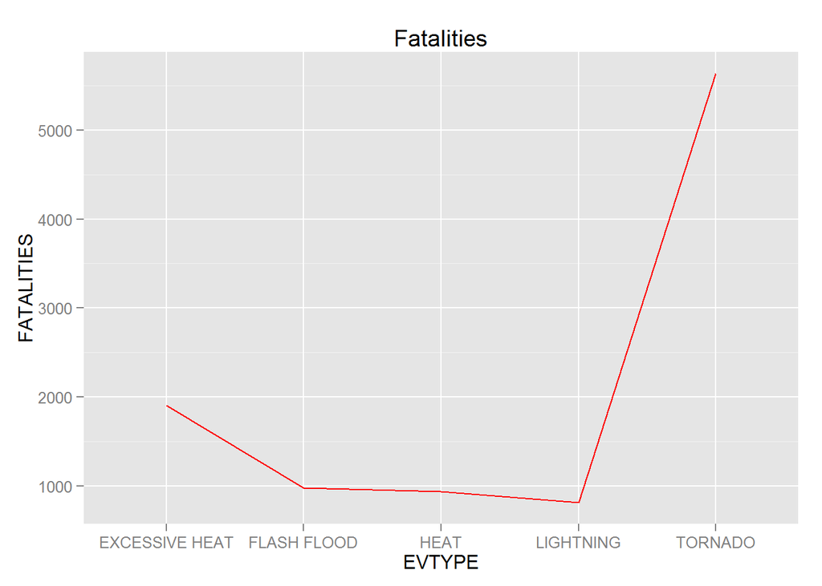

```r
ggplot(top5, aes(x=EVTYPE, y=FATALITIES, group=1)) + geom_line(color="red")+labs(title="Fatalities")
```

We see that tornados are the most harful to population health related to fatalities

```r
#Most Harmful related to injuries
#We use the stormN data frame from above
Most_Injuries <- aggregate(INJURIES~EVTYPE, stormN, sum, na.rm = TRUE)
#Then we need to locate which had the most injuries related to population health
Most_Injuries <-Most_Injuries[order(Most_Injuries$INJURIES, decreasing = TRUE),]
ID_Most_Injuries <- which.max(Most_Injuries[,2])
Most_Injuries[ID_Most_Injuries,]
```

```
##      EVTYPE INJURIES
## 834 TORNADO    91346
```

```r
top5I <- head(Most_Injuries,5)
top5I
```

```
##             EVTYPE INJURIES
## 834        TORNADO    91346
## 856      TSTM WIND     6957
## 170          FLOOD     6789
## 130 EXCESSIVE HEAT     6525
## 464      LIGHTNING     5230
```

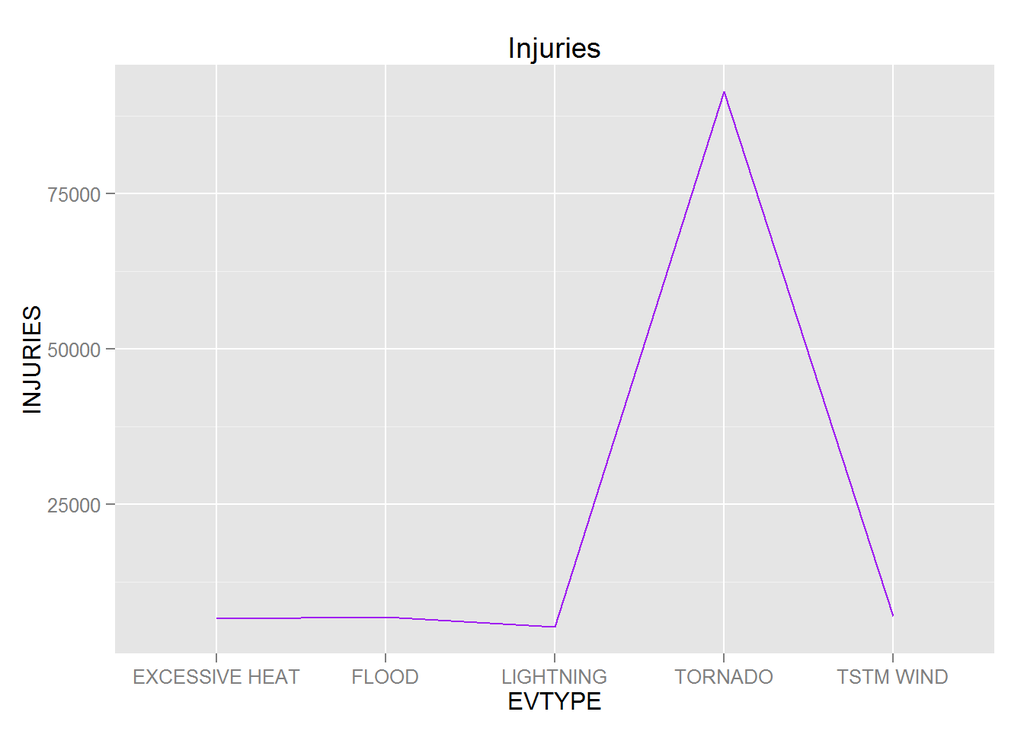

```r
ggplot(top5I, aes(x=EVTYPE, y=INJURIES, group=1)) + geom_line(color="purple")+labs(title="Injuries")
```

We see that tornados are also most harmful to population related to injuries

#### Greatest economic consequences

```r
#Property Damage
#We use the stormN data frame from above
Great_eco_conseq <- aggregate(PROPDMG~EVTYPE, stormN, sum, na.rm = TRUE)
#Then we need to locate which is most harful related to population health
Great_eco_conseq <- Great_eco_conseq[order(Great_eco_conseq$PROPDMG, decreasing = TRUE),]
ID_Great_eco_conseq <- which.max(Great_eco_conseq[,2])
Great_eco_conseq[ID_Great_eco_conseq,]
```

```
##      EVTYPE PROPDMG
## 834 TORNADO 3212258
```

```r
top5E <- head(Great_eco_conseq, 5)
top5E
```

```
##                EVTYPE   PROPDMG
## 834           TORNADO 3212258.2
## 153       FLASH FLOOD 1420124.6
## 856         TSTM WIND 1335965.6
## 170             FLOOD  899938.5
## 760 THUNDERSTORM WIND  876844.2
```

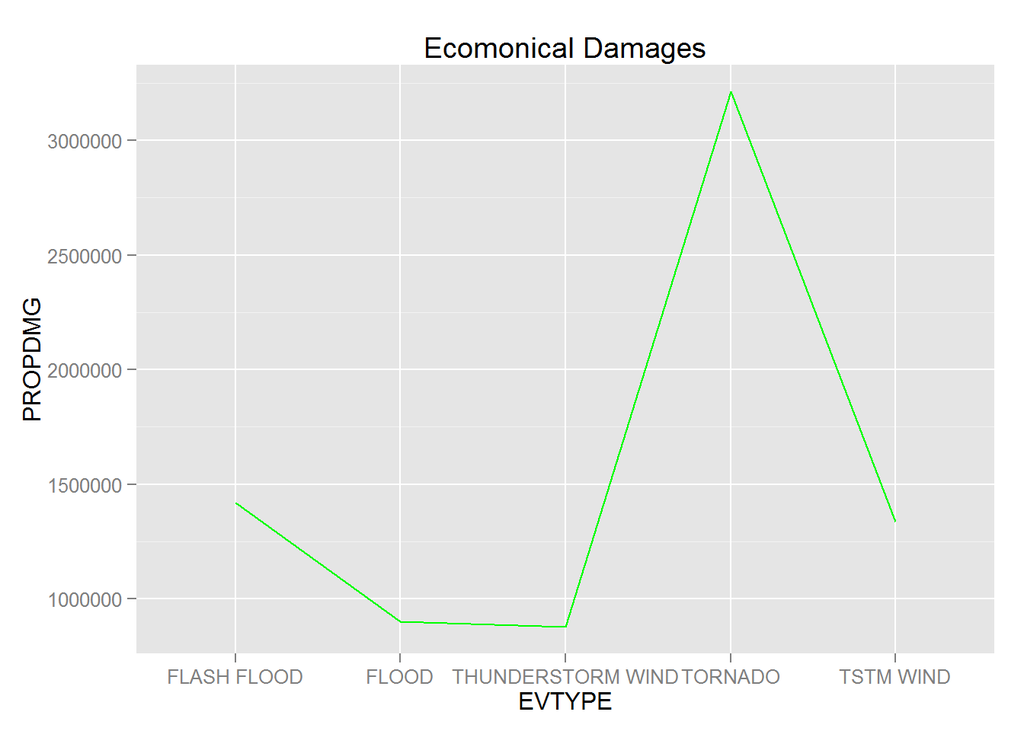

```r
ggplot(top5E, aes(x=EVTYPE, y=PROPDMG, group=1)) + geom_line(color="green") + labs(title="Ecomonical Damages")
```

We see that tornados has the most economical consequence relative to property damage